# IE360hw2

İrem Öztürk

## Introduction

**Liquidated** firm is used for the firms that are in the process of ending. In this project I will try to examine **the number of newly liquidated firms in Turkey** data and come up with a forecast for the April, 2021. To do that I will use time series regression model. Without any examination we can think that some factors like commercial bank loan interest rate, real sector confidence index, unemployment rate, consumer confidence rate or expected production may affect it. In the following section we will look at the relation of them.

##Data Manipulation and Visualization

First of all, I plotted our data and after that looked at the correlation between them.

```
## [1] "C:/Users/oztur/OneDrive/Masaüstü"
```

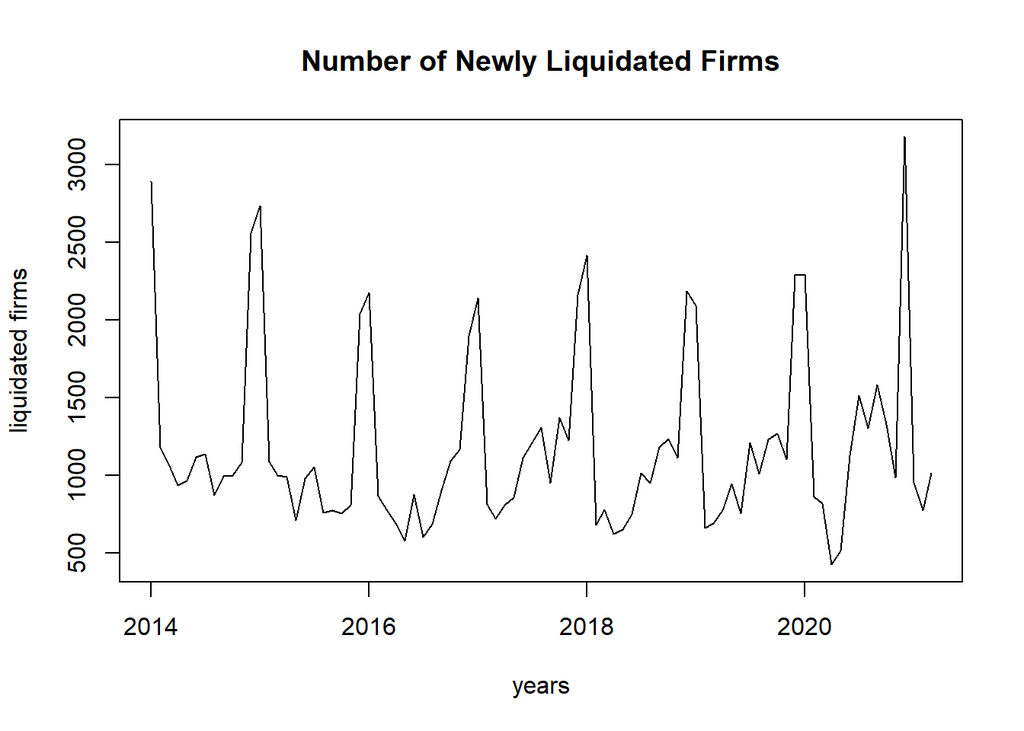

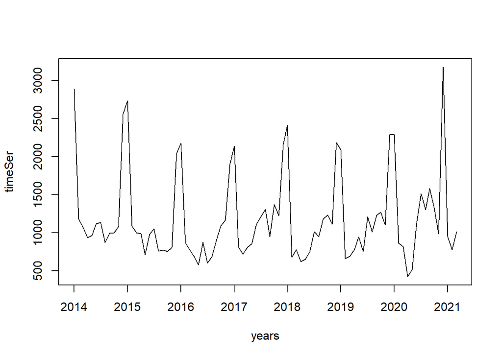

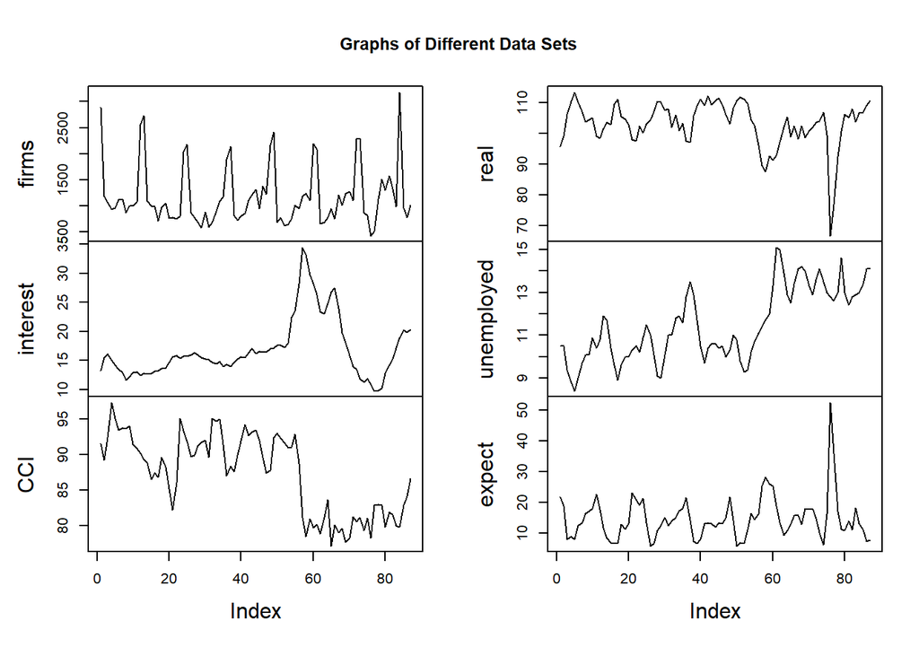

```
##                  firms    interest         CCI       real unemployed     expect
## firms       1.00000000 -0.03125189 -0.09520174 -0.1016357  0.2315059  0.1006713
## interest   -0.03125189  1.00000000 -0.34491804 -0.1912444  0.2338571  0.1247471
## CCI        -0.09520174 -0.34491804  1.00000000  0.4961183 -0.7522237 -0.2865011
## real       -0.10163575 -0.19124436  0.49611829  1.0000000 -0.4006435 -0.8592129
## unemployed  0.23150588  0.23385710 -0.75222369 -0.4006435  1.0000000  0.1582155
## expect      0.10067134  0.12474713 -0.28650113 -0.8592129  0.1582155  1.0000000
```

As we can see there is no very significant correlation between independent variables and our data. However I will try to work with some of them like Unemployment, real sector confidence interval and expected production.

## Regression Model

To start our model I’ll use trend and seasonality parameter. Although, there is not a significant trend in our model, there is an obvious seasonality. At months December and January there is an increase every year.

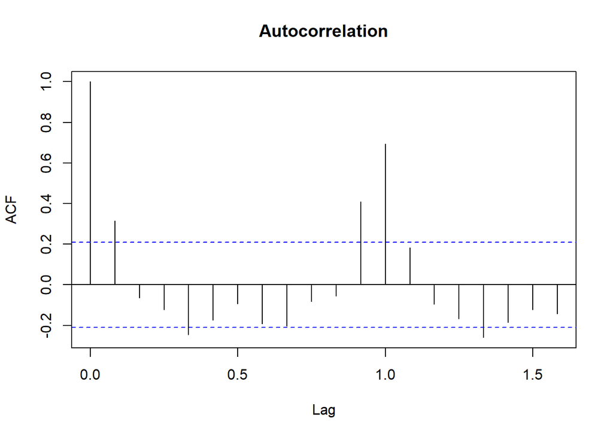

```
##
## Call:
## lm(formula = timeSer ~ trend + as.factor(month), data = total_data)
##
## Residuals:
##      Min       1Q   Median       3Q      Max
## -1232.64  -137.93   -23.19   153.99   867.70
##
## Coefficients:
##                      Estimate Std. Error t value Pr(>|t|)
## (Intercept)         2236.1418   114.2444  19.573  < 2e-16 ***
## trend                 -0.5353     1.2282  -0.436    0.664
## as.factor(month)2  -1344.9647   143.2731  -9.387 3.10e-14 ***
## as.factor(month)3  -1351.8045   143.2889  -9.434 2.53e-14 ***
## as.factor(month)4  -1463.8737   148.3421  -9.868 3.88e-15 ***
## as.factor(month)5  -1466.0527   148.3166  -9.885 3.62e-15 ***
## as.factor(month)6  -1252.5174   148.3014  -8.446 1.86e-12 ***
## as.factor(month)7  -1106.5536   148.2963  -7.462 1.34e-10 ***
## as.factor(month)8  -1226.1612   148.3014  -8.268 4.03e-12 ***
## as.factor(month)9  -1123.3402   148.3166  -7.574 8.25e-11 ***
## as.factor(month)10 -1059.2335   148.3421  -7.140 5.37e-10 ***
## as.factor(month)11 -1140.9839   148.3776  -7.690 4.99e-11 ***
## as.factor(month)12   120.1228   148.4234   0.809    0.421
## ---
## Signif. codes:  0 '***' 0.001 '**' 0.01 '*' 0.05 '.' 0.1 ' ' 1
##
## Residual standard error: 286.5 on 74 degrees of freedom
## Multiple R-squared:  0.7896, Adjusted R-squared:  0.7555
## F-statistic: 23.14 on 12 and 74 DF,  p-value: < 2.2e-16
```

Firstly, we should check the p value from the F test which is very close to zero, so we can say that our model is reasonable, but trend is not a powerful factor to model this series.To evaluate the model we need to check residuals and see if they are independently and identically distributed with zero mean and constant variance.

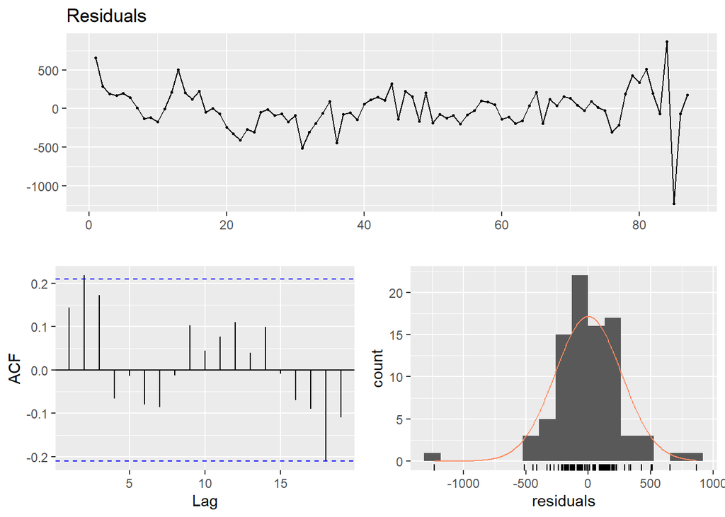

```
##
##  Breusch-Godfrey test for serial correlation of order up to 12
##
## data:  Residuals
## LM test = 22.419, df = 12, p-value = 0.03308
```

The distribution of the residuals is close to normal distribution but variance does not seem constant to eliminate that I can take the log of it.

## Adding Regressors

Even if I can not find a highly correlated data for number of newly liquidated firms, we can try to add them to our model as a regressor and see if it will be meaningful or not.

I added unempolyment rate:

```
##
## Call:
## lm(formula = log_data ~ as.factor(month) + unemployed, data = total_data)
##
## Residuals:
##      Min       1Q   Median       3Q      Max
## -0.79087 -0.11591  0.01428  0.15730  0.40292
##
## Coefficients:
##                     Estimate Std. Error t value Pr(>|t|)
## (Intercept)         7.723413   0.227846  33.897  < 2e-16 ***
## as.factor(month)2  -0.913380   0.117505  -7.773 3.48e-11 ***
## as.factor(month)3  -0.920314   0.118844  -7.744 3.95e-11 ***
## as.factor(month)4  -1.081720   0.127065  -8.513 1.39e-12 ***
## as.factor(month)5  -1.080179   0.128937  -8.378 2.50e-12 ***
## as.factor(month)6  -0.814360   0.125336  -6.497 8.37e-09 ***
## as.factor(month)7  -0.687730   0.122974  -5.592 3.57e-07 ***
## as.factor(month)8  -0.797926   0.123237  -6.475 9.22e-09 ***
## as.factor(month)9  -0.697245   0.123084  -5.665 2.66e-07 ***
## as.factor(month)10 -0.632672   0.122669  -5.158 2.02e-06 ***
## as.factor(month)11 -0.697899   0.123237  -5.663 2.68e-07 ***
## as.factor(month)12  0.078511   0.121906   0.644    0.522
## unemployed         -0.005052   0.016805  -0.301    0.765
## ---
## Signif. codes:  0 '***' 0.001 '**' 0.01 '*' 0.05 '.' 0.1 ' ' 1
##
## Residual standard error: 0.2349 on 74 degrees of freedom
## Multiple R-squared:  0.7287, Adjusted R-squared:  0.6847
## F-statistic: 16.56 on 12 and 74 DF,  p-value: < 2.2e-16
```

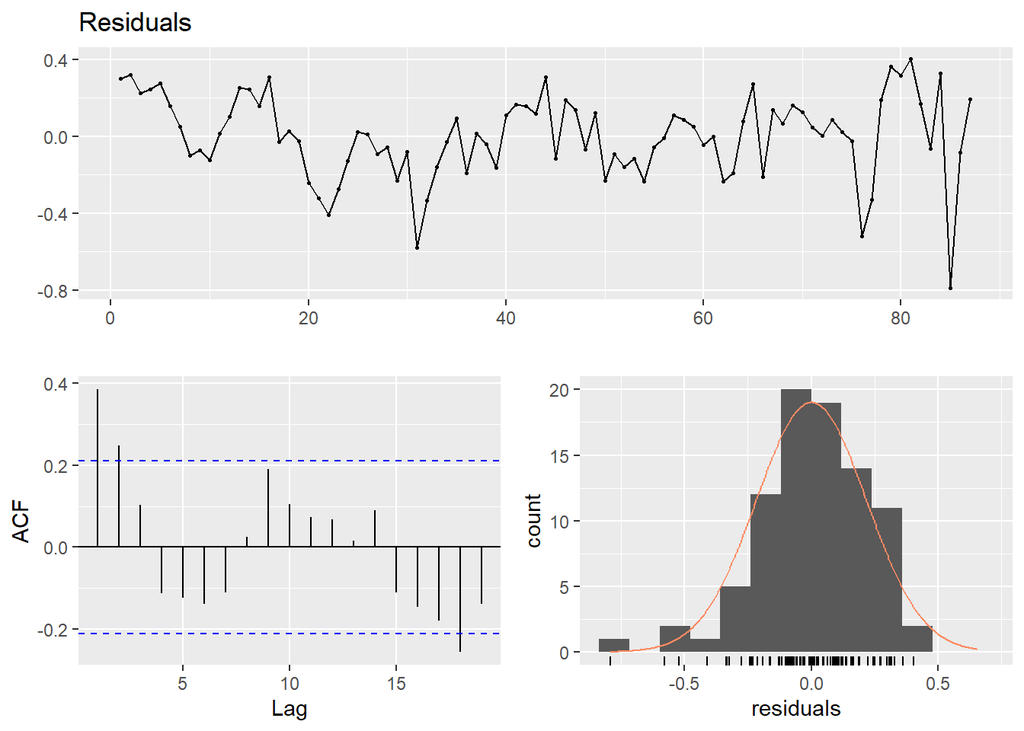

```
##
##  Breusch-Godfrey test for serial correlation of order up to 16
##
## data:  Residuals
## LM test = 36.519, df = 16, p-value = 0.00245
```

From adjusted R- squared value, our model is not improved.

I added real sector confidence index:

```
##
## Call:
## lm(formula = log_data ~ as.factor(month) + unemployed + real,
##     data = total_data)
##
## Residuals:
##      Min       1Q   Median       3Q      Max
## -0.84613 -0.14494  0.02438  0.13912  0.38821
##
## Coefficients:
##                     Estimate Std. Error t value Pr(>|t|)
## (Intercept)         6.762240   0.527539  12.818  < 2e-16 ***
## as.factor(month)2  -0.936616   0.115739  -8.093 9.44e-12 ***
## as.factor(month)3  -0.941955   0.116969  -8.053 1.12e-11 ***
## as.factor(month)4  -1.066602   0.124756  -8.549 1.31e-12 ***
## as.factor(month)5  -1.064456   0.126605  -8.408 2.41e-12 ***
## as.factor(month)6  -0.816258   0.122838  -6.645 4.71e-09 ***
## as.factor(month)7  -0.695512   0.120582  -5.768 1.80e-07 ***
## as.factor(month)8  -0.797133   0.120779  -6.600 5.70e-09 ***
## as.factor(month)9  -0.685682   0.120765  -5.678 2.60e-07 ***
## as.factor(month)10 -0.619347   0.120403  -5.144 2.18e-06 ***
## as.factor(month)11 -0.681343   0.121058  -5.628 3.18e-07 ***
## as.factor(month)12  0.094286   0.119730   0.787    0.434
## unemployed          0.010035   0.018098   0.554    0.581
## real                0.007610   0.003784   2.011    0.048 *
## ---
## Signif. codes:  0 '***' 0.001 '**' 0.01 '*' 0.05 '.' 0.1 ' ' 1
##
## Residual standard error: 0.2302 on 73 degrees of freedom
## Multiple R-squared:  0.7429, Adjusted R-squared:  0.6972
## F-statistic: 16.23 on 13 and 73 DF,  p-value: < 2.2e-16
```

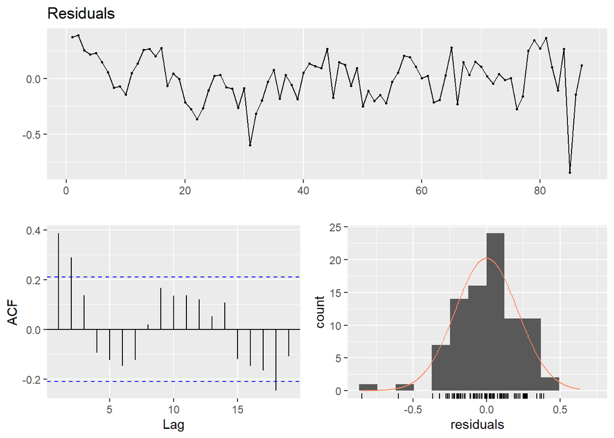

```
##
##  Breusch-Godfrey test for serial correlation of order up to 17
##
## data:  Residuals
## LM test = 35.481, df = 17, p-value = 0.005376
```

F test p value still close to zero. According to adjusted R squared value our model improved. However, both factors I added are not very significant.

I can try the expected production data and the consumer confidence index:

```
##
## Call:
## lm(formula = log_data ~ as.factor(month) + unemployed + real +
##     expect + CCI, data = total_data)
##
## Residuals:
##      Min       1Q   Median       3Q      Max
## -0.81820 -0.09880  0.00425  0.13606  0.47118
##
## Coefficients:
##                     Estimate Std. Error t value Pr(>|t|)
## (Intercept)         9.566495   1.304468   7.334 2.86e-10 ***
## as.factor(month)2  -1.003522   0.116050  -8.647 1.05e-12 ***
## as.factor(month)3  -1.012879   0.118368  -8.557 1.55e-12 ***
## as.factor(month)4  -1.064489   0.126925  -8.387 3.21e-12 ***
## as.factor(month)5  -1.076185   0.131577  -8.179 7.78e-12 ***
## as.factor(month)6  -0.782596   0.125561  -6.233 2.90e-08 ***
## as.factor(month)7  -0.692248   0.118671  -5.833 1.48e-07 ***
## as.factor(month)8  -0.802341   0.119515  -6.713 3.92e-09 ***
## as.factor(month)9  -0.626226   0.127809  -4.900 5.84e-06 ***
## as.factor(month)10 -0.566301   0.126514  -4.476 2.83e-05 ***
## as.factor(month)11 -0.596310   0.130921  -4.555 2.12e-05 ***
## as.factor(month)12  0.166616   0.125944   1.323   0.1901
## unemployed         -0.015824   0.026254  -0.603   0.5486
## real               -0.010137   0.009288  -1.091   0.2788
## expect             -0.022538   0.010100  -2.231   0.0288 *
## CCI                -0.004061   0.007629  -0.532   0.5962
## ---
## Signif. codes:  0 '***' 0.001 '**' 0.01 '*' 0.05 '.' 0.1 ' ' 1
##
## Residual standard error: 0.2242 on 71 degrees of freedom
## Multiple R-squared:  0.7629, Adjusted R-squared:  0.7128
## F-statistic: 15.23 on 15 and 71 DF,  p-value: < 2.2e-16
```

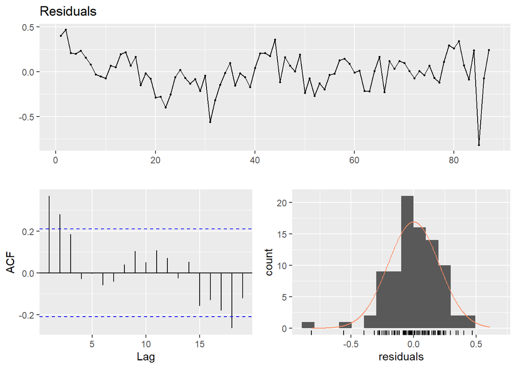

```
##
##  Breusch-Godfrey test for serial correlation of order up to 19
##
## data:  Residuals
## LM test = 32.634, df = 19, p-value = 0.02649
```

```
##
## Call:
## lm(formula = log_data ~ as.factor(month) + expect + real + lag1 +
##     lag2 + unemployed + CCI, data = total_data)
##
## Residuals:
##      Min       1Q   Median       3Q      Max
## -0.76467 -0.09649  0.01556  0.11156  0.37848
##
## Coefficients:
##                     Estimate Std. Error t value Pr(>|t|)
## (Intercept)         4.324126   1.731523   2.497 0.014978 *
## as.factor(month)2  -1.176562   0.142766  -8.241 8.84e-12 ***
## as.factor(month)3  -0.779949   0.188809  -4.131 0.000102 ***
## as.factor(month)4  -0.498548   0.173609  -2.872 0.005462 **
## as.factor(month)5  -0.430710   0.191571  -2.248 0.027851 *
## as.factor(month)6  -0.145749   0.184577  -0.790 0.432523
## as.factor(month)7  -0.198200   0.153856  -1.288 0.202100
## as.factor(month)8  -0.400449   0.143044  -2.799 0.006680 **
## as.factor(month)9  -0.165165   0.159502  -1.035 0.304159
## as.factor(month)10 -0.113736   0.151176  -0.752 0.454481
## as.factor(month)11 -0.174720   0.149146  -1.171 0.245558
## as.factor(month)12  0.554098   0.147857   3.748 0.000374 ***
## expect             -0.033943   0.009090  -3.734 0.000391 ***
## real               -0.021961   0.008418  -2.609 0.011193 *
## lag1                0.292061   0.114085   2.560 0.012728 *
## lag2                0.262363   0.115424   2.273 0.026236 *
## unemployed          0.048561   0.026097   1.861 0.067165 .
## CCI                 0.014690   0.007882   1.864 0.066748 .
## ---
## Signif. codes:  0 '***' 0.001 '**' 0.01 '*' 0.05 '.' 0.1 ' ' 1
##
## Residual standard error: 0.1929 on 67 degrees of freedom
##   (2 observations deleted due to missingness)
## Multiple R-squared:  0.8227, Adjusted R-squared:  0.7777
## F-statistic: 18.28 on 17 and 67 DF,  p-value: < 2.2e-16
```

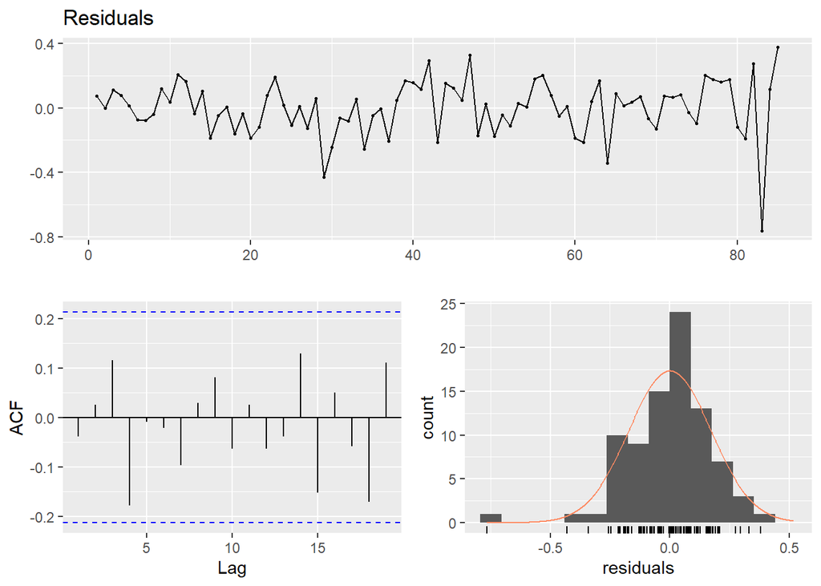

```
##
##  Breusch-Godfrey test for serial correlation of order up to 21
##
## data:  Residuals
## LM test = 23.557, df = 21, p-value = 0.315
```

```
##
## Call:
## lm(formula = log_data ~ as.factor(month) + expect + real + lag1 +
##     lag2 + unemployed + CCI, data = total_data)
##
## Residuals:
##      Min       1Q   Median       3Q      Max
## -0.76467 -0.09649  0.01556  0.11156  0.37848
##
## Coefficients:
##                     Estimate Std. Error t value Pr(>|t|)
## (Intercept)         4.324126   1.731523   2.497 0.014978 *
## as.factor(month)2  -1.176562   0.142766  -8.241 8.84e-12 ***
## as.factor(month)3  -0.779949   0.188809  -4.131 0.000102 ***
## as.factor(month)4  -0.498548   0.173609  -2.872 0.005462 **
## as.factor(month)5  -0.430710   0.191571  -2.248 0.027851 *
## as.factor(month)6  -0.145749   0.184577  -0.790 0.432523
## as.factor(month)7  -0.198200   0.153856  -1.288 0.202100
## as.factor(month)8  -0.400449   0.143044  -2.799 0.006680 **
## as.factor(month)9  -0.165165   0.159502  -1.035 0.304159
## as.factor(month)10 -0.113736   0.151176  -0.752 0.454481
## as.factor(month)11 -0.174720   0.149146  -1.171 0.245558
## as.factor(month)12  0.554098   0.147857   3.748 0.000374 ***
## expect             -0.033943   0.009090  -3.734 0.000391 ***
## real               -0.021961   0.008418  -2.609 0.011193 *
## lag1                0.292061   0.114085   2.560 0.012728 *
## lag2                0.262363   0.115424   2.273 0.026236 *
## unemployed          0.048561   0.026097   1.861 0.067165 .
## CCI                 0.014690   0.007882   1.864 0.066748 .
## ---
## Signif. codes:  0 '***' 0.001 '**' 0.01 '*' 0.05 '.' 0.1 ' ' 1
##
## Residual standard error: 0.1929 on 67 degrees of freedom
##   (2 observations deleted due to missingness)
## Multiple R-squared:  0.8227, Adjusted R-squared:  0.7777
## F-statistic: 18.28 on 17 and 67 DF,  p-value: < 2.2e-16
```

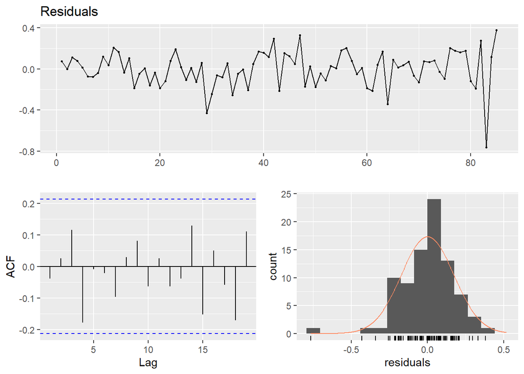

```
##
##  Breusch-Godfrey test for serial correlation of order up to 21
##
## data:  Residuals
## LM test = 23.557, df = 21, p-value = 0.315
```

## Final Model

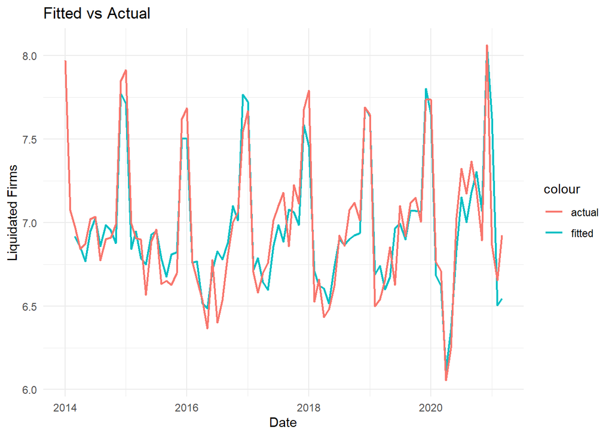

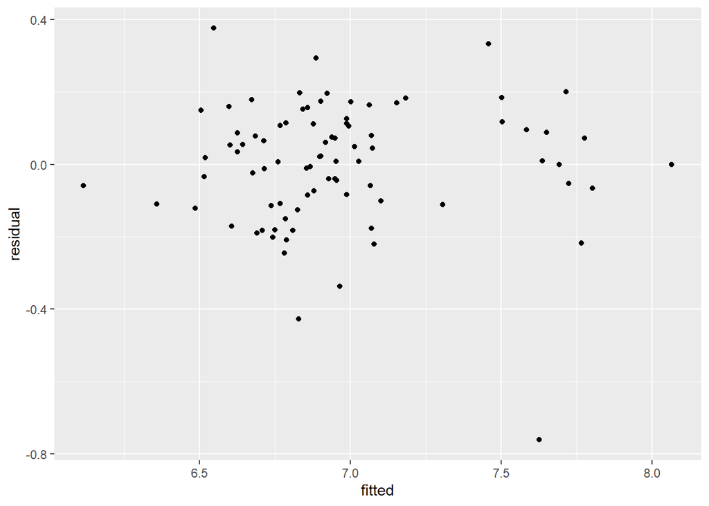

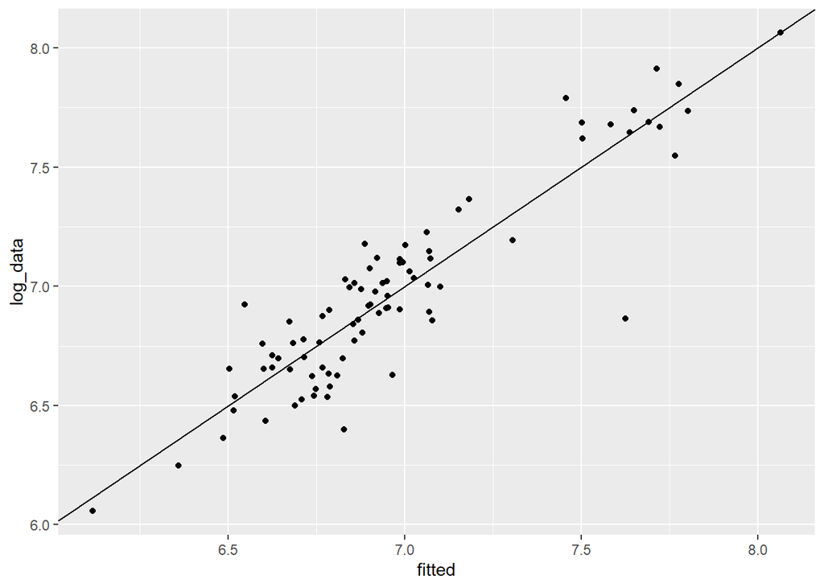

As we can see fitted vs residual plot is not exactly what we wanted because seems like there is a slight relationship between them. The reason of this can be inconstant variance, even though I have tried to make it constant.

##Prediction We don’t have the regressor’s value for the April so I took the values of March to predict the number of newly liquidated firms.

```
##        1
## 360.0647
```

Forecast for April is equal to 360.0647

## Conclusion

In this homework I tried to predict the number of newly liquidated firms in April by using trend, seasonality and the independent factor. Even though, I thought some of the factors would have significant correlation with our model, they haven’t and so they did not improved our model exactly I wanted except the expected production data. In addition, I tried to make our residuals normally distributed with zero mean and constant variance.